# Redes Neuronales-2019-S1

# A saber sobre Python y lo que nos facilita

Python es un lenguaje de programación de alto nivel que nos permite una gran flexibilidad a la hora de trabajar. Tenemos herramientas para abordar problemas de prácticamente todo lo que podamos imaginar.

Nuestro objetivo en el curso es aprender una herramienta que nos permita trabajar con *Redes Neuronales Artificiales*. Algunas de las liberías más conocidas son :

- *Keras*
- *PyTorch*

En este curso aprenderemos a utilizar *Keras*. Un buen punto de partida es el libro del inventor de Keras, Francois Chollet: [Deep Learning with Python](http://file.allitebooks.com/20181223/Deep%20Learning%20with%20Python.pdf)

Pero ojo, una parte importante de trabajar con modelos de Machine Learning es entender y procesar los datos, con esto nos referimos a cómo cargarlos en python, cómo transformarlos, cómo identificar los tipos de datos que nos podemos encontrar, entre otros. Todo esto es importante, pues Keras nos provee de una herramienta poderosa y flexible para construir las redes que queramos, pero una parte importantísima a la hora de abordar un problema es el modelamiento: entender qué y cómo deben ser los datos de entrada (inputs) y de salida (outputs) de la red, además de la arquitectura de la red a utilizar (cantidad de neuronas,capas, funciones activación, optimizador, función de pérdida, etc), la cual va a depender fuertemente del tipo de problema que queramos abordar (clasificación o regresión).

Algunas librerías que puede revisar son:

- Numpy: para trabajar con álgebra lineal.
- Pandas: para trabajar con data frames.
- scikit-learn: muchas herramientas de procesamiento de datos y otros algoritmos de machine learning.
- keras: para construir la arquitectura de red neuronal a utilizar.
- matplotlib: para gráficar.

En lo que sigue presentaremos algunas cosas básicas que debemos conocer para trabajar con python, junto con ciertos tips que pueden ser de utilidad, tanto para programación como para el análisis de sus problemas, todo sustentado con ejemplos replicables.

# Conjuntos de entrenamiento, validación y testeo.

En el contexto del aprendizaje supervisado tenemos la capacidad de evaluar y cuantificar, bajo ciertas métricas, el desempeño de nuestro modelo. Por supuesto que esto aplica directamente a redes neuronales.

En estos problemas nuestro objetivo es entrenar un modelo que sea capaz de predecir/clasificar algún fenómeno en función de cierta información. El proceso se separa en dos:

1. *Etapa de Entrenamiento*: usualemente el 70% u 80% de nuestros datos totales se destina a la etapa de entrenamiento. Estos datos son nuevamente separados en dos conjuntos **disjuntos**:
   - *Conjunto de Entrenamiento:* corresponde al conjunto de datos con el que se entrenará el modelo.
   - *Conjunto de Validación:* corresponde a un pequeño conjunto de datos que, en cada época del entrenamiento se evalúa sobre el modelo. Esto nos dará una idea cercana sobre qué performance tendrá el modelo sobre los datos de entrenamiento. También nos servirá para analizar si nuestro modelo está aprendiendo bien, se está sobre ajustando (overfitting), o está aprendiendo de muy mala manera (underfitting). *Más adelante veremos cómo utilizar los resultados de este conjunto de validación*.
2. *Etapa de Testeo*: los datos restantes luego de elegir los de entrenamiento (30% o 20%). Son utilizados para evaluar el desempeño del modelo entrenado sobre datos que jamás ha visto antes. Si asumimos que nuestros datos son consistentes y los datos de entrenamiento contienen suficientes datos para abarcar la variabilidad de los datos existentes, entonces deberíamos obtener resultados de desempeño similares a los obtenidos en el entrenamiento

# Arquitectura de una red

La arquitectura de una red está compuesta principalmente por:

- La cantidad de capas
- La cantidad de neuronas en cada capa
- Las funciones de activación de cada capa
- Función de pérdida a considerar
- El optimizador
- Las épocas de entrenamiento
- El tamaño de los batches de entrenamiento

La documentación de la librería **keras*** la puede encontrar en su página web oficial https://keras.io/

## Funciones de activación

Algunas de las funciones de activación más usuales son:

### 1) Función Sigmoidal

\begin{equation} g(z) = \dfrac{1}{1+e^{-z}} \end{equation}

### 2) Función Tangente Hiperbólica

\begin{equation} g(z) = \dfrac{e^z - e^{-z}}{e^z+e^{-z}} \end{equation}

### 3) Función ReLU

\begin{equation} g(z) = \max(0,z) \end{equation}

### 4) Funcion Leaky ReLU

\begin{equation} g(z) = \max(\varepsilon z,z) , \varepsilon << 1 \end{equation}

https://keras.io/activations/

## Funciones de pérdida

https://keras.io/losses/

### 1) Categorical crossentropy

### 2) Mean squared error

## Optimizadores

https://keras.io/optimizers/

- 1) SGD
- 2) Adam
- 3) NAdam

*Link de interés* En el paper [An overview of gradient descent optimization algorithms](https://arxiv.org/pdf/1609.04747.pdf) puede encontrar una descripción de los optimizadores descritos (pag 7 y 8 para Adam y Nadam, respectivamente).

*Graficaremos algunas funciones de activación*

```python
import matplotlib.pyplot as plt
import numpy as np
#%matplotlib inline
%matplotlib notebook


# Definir la función sigmoidal
def sigmoid(z):
    return(1/(1+ np.exp(1)**-z))

# Función Tangente Hiperbólica
def tanh(z):
    return (np.exp(1) - np.exp(1)**-z) / (np.exp(1) + np.exp(1)**-z)

# Función ReLU
def relu(z):
    return max(0.0,z)

# Función Leaky ReLU
def leakyrelu(z, eps=0.1):
    'Por defecto se definió un eps = 0.01'
    return max(eps*z,z)

# Vectorizar las funciones
Sigmoid = np.vectorize(sigmoid)
Tanh    = np.vectorize(tanh)
Relu    = np.vectorize(relu)
LeakyRelu = np.vectorize(leakyrelu)

# Generar un vector desde -10 hasta 10 con 200 elementos equiespaciados
z = np.linspace(start=-10,stop=10,num=200)

## Graficamos las funciones
# Sigmoidal
plt.subplot(221)
plt.plot(z, Sigmoid(z))
plt.title('Función Sigmoidal')
plt.ylabel('sigmoid')
plt.xlabel('z')
plt.grid(True)

# Tangente Hiperbólica
plt.subplot(222)
plt.plot(z, Tanh(z))
plt.title('Función tanh')
plt.ylabel('tanh')
plt.xlabel('z')
plt.grid(True)

# ReLU
plt.subplot(223)
plt.plot(z, Relu(z))
plt.title('Función ReLU')
plt.ylabel('tanh')
plt.xlabel('z')
plt.grid(True)


# Leaky ReLU
plt.subplot(224)
plt.plot(z, LeakyRelu(z))
plt.title('Función Leaky ReLU')
plt.ylabel('tanh')
plt.xlabel('z')
plt.grid(True)

plt.subplots_adjust(top=0.92, bottom=0.08, left=0.10, right=0.95, hspace=0.5,
                    wspace=0.5)
```

[output not shown]

# 1. *Numpy y Pandas*: Trabajando con datos.

Usualmente, los datos son guardados en bases de datos. Para trabajarlos en forma local (en nuestros computadores), es usual descargarlos en archivos del tipo *.txt, .csv, .xlsx, .json*, u otros. Uno de los primeros pasos para poder trabajar con ellos en Python (y en cualquier lenguaje de programación o software que estemos utilizando) es cargarlos como una variable local.

Para nuestro curso, los datos estarán usualemente tabulados en formatos *.txt, .csv o .xlsx*. Estos archivos estarán almacenados en el disco duro de nuestros computadores (disco D o C) y para realizar una lectura de estos datos y cargarlos en la memoria RAM de nuestro computador, para así poder ser utilizados en Python, utilizaremos la librería Pandas para cargarlos como una variable local.

## Recursos de interés

DataCamp es una de plataforma web donde enseñan a trabajar en *Data Science* (ciencia de datos). En Data Science se utilizan principalmente los lenguajes de programación R, Python y SQL (este último para realizar consultas a una base de datos).

Particularmente, en cuanto a Python, tiene un curso básico, que puede tomar para interiorizarse en las operaciones básicas de este lenguaje DataCamp

Adicionalmente, aquí tiene dos links para *Cheat Sheets* de Pandas y Numpy:

- [Pandas](https://s3.amazonaws.com/assets.datacamp.com/blog_assets/PandasPythonForDataScience.pdf)
- [Numpy](https://s3.amazonaws.com/assets.datacamp.com/blog_assets/Numpy_Python_Cheat_Sheet.pdf)

## Otros

Página que contiene papers que comparten sus códigos de programación. Puede revisar el estado del arte para los distintos campos en los que se está utilizando inteligencia artificial. Visite este sitio web

## Leyendo datos con Pandas.

```python
# Importar la librería
import pandas as pd

# Formas de leer un archivo
pd.read_csv('path/to/my/file.csv') # Para leer archivos .csv y .txt
pd.read_excel('path/to/my/file.xlsx') # Para archivos excel .xlsx
```

[output not shown]

Por supuesto que al ejecutar la celda anterior se encontrará con un error, pues no hay ningún archivo en su computadora llamado 'file.csv' o 'file.xlsx', ni un directorio 'path/to/my/'

Para comenzar de manera práctica, tomaremos el archivo *Mall_Customers.csv* que se encuentra en http://www.atakovat.com/rn/ .

*El contexto de los datos es el siguiente:* Usted es dueñ@ de un Mall y a través de las tarjetas de membresía tiene algunos datos básicos de sus clientes, como la edad, el género, su ingreso anual y sus gastos, evaluados en una escala de 1-100.

*Cargue los datos y piense en todas las formas posibles de formular un problema en base a los datos, que le ayude a tomar decisiones para generar más ingresos en su Mall*

```python
# Ahora sí, importamos correctamente la librería
import pandas as pd

# Directorio donde se encuentra el archivo 'ejemplo.csv' en su computador
path = '/Users/jorgeavilacartes/Documents/Universidad/Redes Neuronales 2019/'
print('El archivo se encuentra en: ' + path + 'Mall_Customers.csv')
```

```
El archivo se encuentra en: /Users/jorgeavilacartes/Documents/Universidad/Redes Neuronales 2019/Mall_Customers.csv
```

```python
# Leemos los datos y los guardamos en una variable llamada 'df'
df = pd.read_csv( path + 'Mall_Customers.csv')
df.head(5) # Para ver los primeros 5 registros
```

|  | CustomerID | Gender | Age | Annual Income (k$) | Spending Score (1-100) |
| --- | --- | --- | --- | --- | --- |
| 0 | 1 | Male | 19 | 15 | 39 |
| 1 | 2 | Male | 21 | 15 | 81 |
| 2 | 3 | Female | 20 | 16 | 6 |
| 3 | 4 | Female | 23 | 16 | 77 |
| 4 | 5 | Female | 31 | 17 | 40 |

```python
# PUEDE SER UTIL
import os
print( 'Los archivos que hay en el directorio definido en la variable <path> son: ' )
for file in os.listdir(path):
    print(file)
```

```
Los archivos que hay en el directorio definido en la variable <path> son:
Redes Neuronales-2019-S1.tex
Mall_Customers.csv
Redes Neuronales-2019-S1.ipynb
heart0.csv
ejemplo.csv
Redes Neuronales-2019-S1.pdf
Redes Neuronales-2019-S1.html
```

```python
# Para ver los últimos 5 registros
df.tail(5)
```

|  | CustomerID | Gender | Age | Annual Income (k$) | Spending Score (1-100) |
| --- | --- | --- | --- | --- | --- |
| 195 | 196 | Female | 35 | 120 | 79 |
| 196 | 197 | Female | 45 | 126 | 28 |
| 197 | 198 | Male | 32 | 126 | 74 |
| 198 | 199 | Male | 32 | 137 | 18 |
| 199 | 200 | Male | 30 | 137 | 83 |

```python
# Ver el nombre de las columnas (nuestras variables disponibles)
df.columns
```

```
Index(['CustomerID', 'Gender', 'Age', 'Annual Income (k$)',
       'Spending Score (1-100)'],
      dtype='object')
```

```python
# Guardar una lista con los nombres de las columnas
cols = df.columns.values
print(cols)
```

```
['CustomerID' 'Gender' 'Age' 'Annual Income (k$)' 'Spending Score (1-100)']
```

```python
# Obtener información sobre las variables involucradas y los valores que contiene cada columna
df.info()
```

```
<class 'pandas.core.frame.DataFrame'>
RangeIndex: 200 entries, 0 to 199
Data columns (total 5 columns):
CustomerID                200 non-null int64
Gender                    200 non-null object
Age                       200 non-null int64
Annual Income (k$)        200 non-null int64
Spending Score (1-100)    200 non-null int64
dtypes: int64(4), object(1)
memory usage: 7.9+ KB
```

```python
# Obtener un resumen estadístico de las variables numéricas
df.describe()
```

|  | CustomerID | Age | Annual Income (k$) | Spending Score (1-100) |
| --- | --- | --- | --- | --- |
| count | 200.000000 | 200.000000 | 200.000000 | 200.000000 |
| mean | 100.500000 | 38.850000 | 60.560000 | 50.200000 |
| std | 57.879185 | 13.969007 | 26.264721 | 25.823522 |
| min | 1.000000 | 18.000000 | 15.000000 | 1.000000 |
| 25% | 50.750000 | 28.750000 | 41.500000 | 34.750000 |
| 50% | 100.500000 | 36.000000 | 61.500000 | 50.000000 |
| 75% | 150.250000 | 49.000000 | 78.000000 | 73.000000 |
| max | 200.000000 | 70.000000 | 137.000000 | 99.000000 |

|  | CustomerID | Age | Annual Income (k$) | Spending Score (1-100) |
| --- | --- | --- | --- | --- |
| count | 200.000000 | 200.000000 | 200.000000 | 200.000000 |
| mean | 100.500000 | 38.850000 | 60.560000 | 50.200000 |
| std | 57.879185 | 13.969007 | 26.264721 | 25.823522 |
| min | 1.000000 | 18.000000 | 15.000000 | 1.000000 |
| 25% | 50.750000 | 28.750000 | 41.500000 | 34.750000 |
| 50% | 100.500000 | 36.000000 | 61.500000 | 50.000000 |
| 75% | 150.250000 | 49.000000 | 78.000000 | 73.000000 |
| max | 200.000000 | 70.000000 | 137.000000 | 99.000000 |

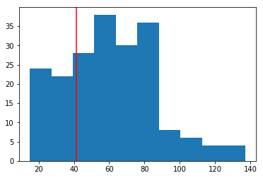

```python
# Podemos observar algunas cosas respecto a la tabla.
import matplotlib.pyplot as plt
%matplotlib inline

# Un histograma de las variables numéricas observadas
plt.hist(df['Annual Income (k$)'])
plt.axvline(x= 41.5, color ='red')
df.describe()
```

```python
df['Gender'].value_counts()
```

```
Female    112
Male       88
Name: Gender, dtype: int64
```

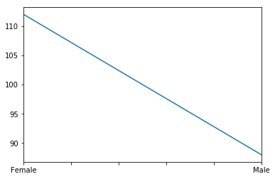

```python
# Pero también de las variables numéricas categóricas
df['Gender'].value_counts().plot()
```

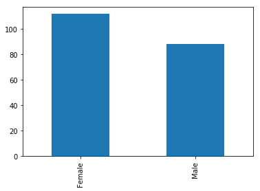

```python
df['Gender'].value_counts().plot(kind = 'bar')
```

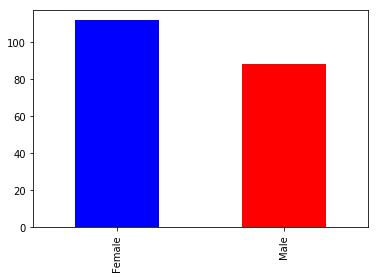

```python
df['Gender'].value_counts().plot(kind = 'bar', color = ['blue','red'])
```

```python
resumen = df['Gender'].value_counts()
(resumen/ resumen.sum() )*100
```

```
Female    56.0
Male      44.0
Name: Gender, dtype: float64
```

*Ahora que ya vimos los datos y dieron ideas, supongamos dos situaciones y trabajemos en ellas*

## Situación 1: Conozco todas las variables salvo el "Annual Income" 😨

### Verlo como un problema de regresión

En este caso, nuestra variable "Annual Income" será una variable numérica a predecir.

**Preparación de los datos** En el caso de las redes neuronales, estas trabajan con variables numéricas solamente, por lo tanto, toda variable categórica debe ser representada como variables dummy (o en su hot encoding):

```python
# Variables categóricas a variables dummy / Hot Encode
GenderDummy = pd.get_dummies(df['Gender'])
GenderDummy.head()
```

|  | Female | Male |
| --- | --- | --- |
| 0 | 0 | 1 |
| 1 | 0 | 1 |
| 2 | 1 | 0 |
| 3 | 1 | 0 |
| 4 | 1 | 0 |

```python
# Recopilar las variables numéricas a utilizar
numcols = ['Age', 'Spending Score (1-100)', 'Annual Income (k$)']
dfNum = df[numcols]
dfNum.head()
```

|  | Age | Spending Score (1-100) | Annual Income (k$) |
| --- | --- | --- | --- |
| 0 | 19 | 39 | 15 |
| 1 | 21 | 81 | 15 |
| 2 | 20 | 6 | 16 |
| 3 | 23 | 77 | 16 |
| 4 | 31 | 40 | 17 |

```python
# Obtener nueva tabla al concatenar la dfNum y GenderDummy
Data = pd.concat([ GenderDummy,dfNum ], axis = 1)
Data.head()
```

|  | Female | Male | Age | Spending Score (1-100) | Annual Income (k$) |
| --- | --- | --- | --- | --- | --- |
| 0 | 0 | 1 | 19 | 39 | 15 |
| 1 | 0 | 1 | 21 | 81 | 15 |
| 2 | 1 | 0 | 20 | 6 | 16 |
| 3 | 1 | 0 | 23 | 77 | 16 |
| 4 | 1 | 0 | 31 | 40 | 17 |

*Algo que puede ser de utilidad cuando se deben ejecutar operaciones sobre gran cantidad de datos, es tener una barra de progreso que nos de una idea de cuánto tiempo demorará tal ejecución. Veamos un ejemplo*

```python
# Algo util cuando se trabaja con largos conjuntos de datos y tediosas operaciones:
from tqdm._tqdm_notebook import tqdm_notebook
tqdm_notebook.pandas()

## Desde Spyder
# import tqdm as tqdm
# tqdm.pandas()
# instalar con pip:  pip install tqdm

lista = []
# Ejemplo para ver su utilidad
for x in tqdm_notebook(range(10000000)):
    valor = x**2+x-100*x*30*x
    lista.extend([valor])
```

```python
import pandas as pd
# Pero esto es algo que podemos usar directamente sobre un DataFrame o un
Resultado = pd.Series(range(10000000)).progress_apply(lambda x: x**2+x-100*x*30*x)
```

*Pero también podemos medir los segundos transcurridos en un proceso con la librería time*

```python
from time import time
ti = time()
if all(lista == Resultado): print('Los resultados son los mismos')
tf = time() - ti
print('Han pasado ' + str(tf) + ' segundos.')
```

```
Los resultados son los mismos
Han pasado 2.6915781497955322 segundos.
```

Una *buena práctica* es reescalar los datos, de modo de tener a todos en un rango similar. Ejemplos de esto son la estandarización al intervalo $[0,1]$, $[-1,1]$ o una normalización del tipo $\dfrac{x-\mu}{\sigma}$, donde $\mu$ es el promedio de las observaciones de una variable específica y $\sigma$ su desviación estándar.

# Escalamientos clásicos para un dato

Supongamos que un dato $x$ de una muestra $X = {x_1,...,x_n}$ lo queremos reescalar a un valor $z$. Conocemos $\mu$ (el promedio de la muestra $X$), $\sigma$ (su desviación estándar), $\max$ y $\min$ de $X$.

### Al intervalo $[0,1]$

Note que aquí necesitamos encontrar una función $f: Dom(f) \subset \mathbb{R} \rightarrow [0,1]$ donde $Dom(f) = [\min, \max]$.

### Normalizar como una $\mathcal{N}(0,1)$

Otro escalamiento clásico es normalizar los datos, es decir, obligarlos a que el promedio de los datos transformados sea igual a 0, y que su desviación estándar sea 1. Esto hará que la mayoría de los datos viva alrededor del 0, variando entre $-1$ y $1$ (pero ojo, la mayoría, no todos).

$$z = \dfrac{x-\mu}{\sigma}$$

A continuación puede ver un esquema de cómo se distribuirían los datos. [Puede leer más acá](https://es.wikipedia.org/wiki/Distribuci%C3%B3n_normal)

```python
Image(url = 'https://upload.wikimedia.org/wikipedia/commons/thumb/3/3a/Standard_deviation_diagram_micro.svg/1280px-Standard_deviation_diagram_micro.svg.png')
```

[figure not shown]

Usando la librería *sklearn*, tenemos herramientas para hacer estos procesamientos en los datos:

```python
from sklearn.preprocessing import StandardScaler, MinMaxScaler

# Definimos una función para escalar nuestra columna
scalerMinMax = MinMaxScaler(feature_range=(0,1)) # feature_range recibe el rango (min,max) donde quiero escalar

# Escalamos la edad al intervalo 0,1
AgeScale = scalerMinMax.fit_transform(Data[['Age']])
AgeScale
```

```
array([[0.01923077],
       [0.05769231],
       [0.03846154],
       [0.09615385],
       [0.25      ],
       [0.07692308],
       [0.32692308],
       [0.09615385],
       [0.88461538],
       [0.23076923],
       [0.94230769],
       [0.32692308],
       [0.76923077],
       [0.11538462],
       [0.36538462],
       [0.07692308],
       [0.32692308],
       [0.03846154],
       [0.65384615],
       [0.32692308],
       [0.32692308],
       [0.13461538],
       [0.53846154],
       [0.25      ],
       [0.69230769],
       [0.21153846],
       [0.51923077],
       [0.32692308],
       [0.42307692],
       [0.09615385],
       [0.80769231],
       [0.05769231],
       [0.67307692],
       [0.        ],
       [0.59615385],
       [0.05769231],
       [0.46153846],
       [0.23076923],
       [0.34615385],
       [0.03846154],
```

[output cut: 145 more lines]

```
       [0.23076923],
       [0.69230769],
       [0.19230769],
       [0.44230769],
       [0.34615385],
       [0.30769231],
       [0.26923077],
       [0.28846154],
       [0.38461538],
       [0.55769231],
       [0.32692308],
       [0.51923077],
       [0.26923077],
       [0.26923077],
       [0.23076923]])
```

```python
# Si quisieramos normalizar los datos, podemos usar StandardScaler
scalerNorm = StandardScaler()
AgeNorm = scalerNorm.fit_transform(Data[['Age']])
```

```python
# Ahora debemos incluir esta información en nuestra tabla para el entrenamiento
Data.head()
#Data['Age'] = AgeScale
```

|  | Female | Male | Age | Spending Score (1-100) | Annual Income (k$) |
| --- | --- | --- | --- | --- | --- |
| 0 | 0 | 1 | 19 | 39 | 15 |
| 1 | 0 | 1 | 21 | 81 | 15 |
| 2 | 1 | 0 | 20 | 6 | 16 |
| 3 | 1 | 0 | 23 | 77 | 16 |
| 4 | 1 | 0 | 31 | 40 | 17 |

```python
Data['Age'] = AgeScale
Data.head()
```

|  | Female | Male | Age | Spending Score (1-100) | Annual Income (k$) |
| --- | --- | --- | --- | --- | --- |
| 0 | 0 | 1 | 0.019231 | 39 | 15 |
| 1 | 0 | 1 | 0.057692 | 81 | 15 |
| 2 | 1 | 0 | 0.038462 | 6 | 16 |
| 3 | 1 | 0 | 0.096154 | 77 | 16 |
| 4 | 1 | 0 | 0.250000 | 40 | 17 |

*¿Cómo lo hacemos para las demás variables?*

```python
# Desarrollar en clases...
Data['Spending Score (1-100)'] = scalerMinMax.fit_transform(Data[['Spending Score (1-100)']])
Data.head()
```

|  | Female | Male | Age | Spending Score (1-100) | Annual Income (k$) |
| --- | --- | --- | --- | --- | --- |
| 0 | 0 | 1 | 0.019231 | 0.387755 | 15 |
| 1 | 0 | 1 | 0.057692 | 0.816327 | 15 |
| 2 | 1 | 0 | 0.038462 | 0.051020 | 16 |
| 3 | 1 | 0 | 0.096154 | 0.775510 | 16 |
| 4 | 1 | 0 | 0.250000 | 0.397959 | 17 |

*Ahora que tenemos nuestros datos escalados, debemos elegir nuestros conjuntos de entrenamiento y testeo para luego entrenar una red*

```python
Data['Annual Income (k$)'] = scalerMinMax.fit_transform(Data[['Annual Income (k$)']])
Data.head()
```

|  | Female | Male | Age | Spending Score (1-100) | Annual Income (k$) |
| --- | --- | --- | --- | --- | --- |
| 0 | 0 | 1 | 0.019231 | 0.387755 | 0.000000 |
| 1 | 0 | 1 | 0.057692 | 0.816327 | 0.000000 |
| 2 | 1 | 0 | 0.038462 | 0.051020 | 0.008197 |
| 3 | 1 | 0 | 0.096154 | 0.775510 | 0.008197 |
| 4 | 1 | 0 | 0.250000 | 0.397959 | 0.016393 |

```python
# Separar el conjunto total de datos en entrenamiento y testeo.
import numpy as np

# Elegimos una cantidad
porcTrain = 0.7 # Porcentaje de los datos a considerar en el entrenamiento
Ntrain = int(Data.shape[0]//(1/porcTrain)) # Cantidad de elementos en el conjunto de entrenamiento
lista  = Data.index.tolist() # La lista de los indices

# Seleccionar lista de indices de Data para el entrenamiento
sampleTrain = np.random.choice(
                  a       = lista,         # Lista sobre la cual elegiré mi muestra
                  size    = Ntrain,        # Cantidad de elementos que quiero retornar
                  replace = False       # Con reemplazo o no
                )

# Seleccionar los indices restantes para dejar en el conjunto de testeo
sampleTest = [ind for ind in set(lista) - set(sampleTrain)]
```

```python
print('Cantidad de elementos en el conjunto de entrenamiento: ' + str(len(sampleTrain)))
print('En el conjunto de test: ' + str(len(sampleTest)))
print('Entrenamiento + Testeo = ' + str(len(sampleTrain) + len(sampleTest)))
```

```
Cantidad de elementos en el conjunto de entrenamiento: 139
En el conjunto de test: 61
Entrenamiento + Testeo = 200
```

```python
colsInput = ['Female', 'Male', 'Age', 'Spending Score (1-100)']
InputTrain  = Data.loc[sampleTrain, colsInput]
OutputTrain = Data.loc[sampleTrain, 'Annual Income (k$)']
```

```python
# Importar librería keras
from keras.models import Sequential
from keras.layers import Dense

# Crear Modelo secuencial
model = Sequential()

# Agregamos capas a nuestro modelo
model.add(Dense(10, input_dim = InputTrain.shape[1], activation = 'relu')) # Primero la capa de entrada
model.add(Dense(12,activation = 'relu')) # Agregando capas
model.add(Dense(1, activation = 'softmax')) #¿Es correcta la función de salida? Explique por qué.

model.summary()
```

```
_________________________________________________________________
Layer (type)                 Output Shape              Param #
=================================================================
dense_52 (Dense)             (None, 10)                50
_________________________________________________________________
dense_53 (Dense)             (None, 12)                132
_________________________________________________________________
dense_54 (Dense)             (None, 1)                 13
=================================================================
Total params: 195
Trainable params: 195
Non-trainable params: 0
_________________________________________________________________
```

```python
# Compilar el modelo
model.compile(loss='mean_squared_error', optimizer='adam', metrics=['mean_squared_error'])
```

```python
# Entrenar el modelo
history = model.fit(InputTrain, OutputTrain, validation_split=0.3, epochs=10, batch_size=10)
```

```
Train on 97 samples, validate on 42 samples
```

```python
# Esto es lo que queda guardado del entrenamiento, un dato por cada época realizada,
# compare con lo que quedó impreso del entrenamiento en la celda anterior con lo que se muestra:
history.history
```

```
{'val_loss': [0.351195270106906,
  0.351195270106906,
  0.351195270106906,
  0.351195270106906,
  0.351195270106906,
  0.351195270106906,
  0.351195270106906,
  0.351195270106906,
  0.351195270106906,
  0.351195270106906],
 'val_mean_squared_error': [0.351195270106906,
  0.351195270106906,
  0.351195270106906,
  0.351195270106906,
  0.351195270106906,
  0.351195270106906,
  0.351195270106906,
  0.351195270106906,
  0.351195270106906,
  0.351195270106906],
 'loss': [0.4653526894825021,
  0.4653526821087316,
  0.465352675349442,
  0.4653526670539502,
  0.465352670433595,
  0.4653526839521742,
  0.4653526695118737,
  0.46535266981911416,
  0.4653526818014912,
  0.4653526827232125],
 'mean_squared_error': [0.4653526894825021,
  0.4653526821087316,
  0.465352675349442,
  0.4653526670539502,
  0.465352670433595,
  0.4653526839521742,
  0.4653526695118737,
  0.46535266981911416,
  0.4653526818014912,
  0.4653526827232125]}
```

### Plotear los resultados del entrenamiento

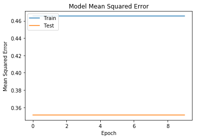

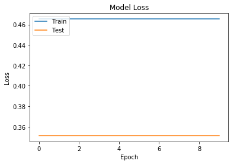

```python
import matplotlib.pyplot as plt

# Plot training & validation accuracy values
plt.plot(history.history['mean_squared_error'])
plt.plot(history.history['val_mean_squared_error'])
plt.title('Model Mean Squared Error')
plt.ylabel('Mean Squared Error')
plt.xlabel('Epoch')
plt.legend(['Train', 'Test'], loc='upper left')
plt.show()

# Plot training & validation loss values
plt.plot(history.history['loss'])
plt.plot(history.history['val_loss'])
plt.title('Model Loss')
plt.ylabel('Loss')
plt.xlabel('Epoch')
plt.legend(['Train', 'Test'], loc='upper left')
plt.show()
```

*Claramente las gráficas se ven raras* Esto se debe a que estamos trabajando un problema de regresión, pero la función softmax se utiliza para problemas de clasificación.

Cambiemos la función de activación softmax por sigmoid y veamos qué pasa...

```
Train on 97 samples, validate on 42 samples
```

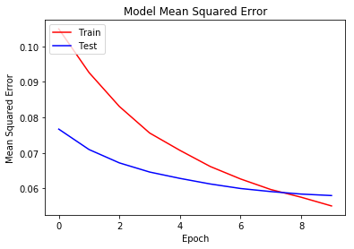

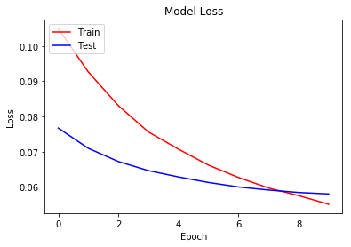

```python
# Crear Modelo secuencial
model = Sequential()

# Agregamos capas a nuestro modelo
model.add(Dense(10, input_dim = InputTrain.shape[1], activation = 'relu')) # Primero la capa de entrada
model.add(Dense(12,activation = 'relu')) # Agregando capas

#      Aquí hacemos el cambio
#############################################
model.add(Dense(1, activation = 'sigmoid')) #
#############################################

## Todo lo demás sigue igual
# Compilar el modelo
model.compile(loss='mean_squared_error', optimizer='adam', metrics=['mean_squared_error'])

# Entrenar el modelo
history = model.fit(InputTrain, OutputTrain, validation_split=0.3, epochs=10, batch_size=10)

import matplotlib.pyplot as plt

# Plot training & validation accuracy values
plt.plot(history.history['mean_squared_error'], color = 'red')
plt.plot(history.history['val_mean_squared_error'], color = 'blue')
plt.title('Model Mean Squared Error')
plt.ylabel('Mean Squared Error')
plt.xlabel('Epoch')
plt.legend(['Train', 'Test'], loc='upper left')
plt.show()

# Plot training & validation loss values
plt.plot(history.history['loss'], color = 'red')
plt.plot(history.history['val_loss'], color = 'blue')
plt.title('Model Loss')
plt.ylabel('Loss')
plt.xlabel('Epoch')
plt.legend(['Train', 'Test'], loc='upper left')
plt.show()
```

# Conclusiones

*Para identificar un buen modelo, puede buscar una gráfica del estilo siguiente*

*¿Ahora se preguntará cómo identificar los demás sucesos?* Pues tenemos otras opciones, podríamos obtener una gráfico como la siguiente:

```python
Image(url='https://stanford.edu/~shervine/images/deep-learning-just-right.png')
```

[figure not shown]

El **caso ideal** sería tener tanto la curva de entrenamiento como la de validación lo más juntas posibles, y lo más cercanas al eje horizontal posible (es decir, un error tendiendo a 0, tanto en conjuntos de entrenamiento, como en aquellos de nunca ha visto).

```python
Image(url='https://stanford.edu/~shervine/images/deep-learning-underfit.png')
```

[figure not shown]

La cual nos permite concluir que el modelo se comporta de una manera similar en el conjunto de entrenamiento y testeo, pero se aleja mucho del erro cuadrático medio 0, por lo tanto, no está siendo capaz de aprender el comportamiento de los datos. Esto lo conocemos como el **Underfitting**

Otra situación que podemos encontrar es el **Overfitting**, situación en la cual el modelo se sobre ajusta a los datos de entrenamiento, es decir, los memoriza, y no es capaz de generalizar a datos nuevos, que serían los datos de testeo.

El overfitting se podría ver de la siguiente forma:

```python
Image(url = 'https://stanford.edu/~shervine/images/deep-learning-overfit.png')
```

[figure not shown]

*¿Hay alguna manera de usar el overfitting a mi favor?* El usar demasiadas épocas tiene la desventaja de que es altamente probable entrar en overfitting, pues los datos pasarán tantas veces por la red que esta tenderá a memorizarlos, pero si nuestro modelo se fue entrenando bien hasta cierta época, podríamos querer quedarnos con el mejor modelo que se haya entrenado (luego de cada época tenemos un modelo distinto, pues son nuevos pesos los que se actualizan).

Afortunadamente tenemos una forma sencilla de hacer esto. Es una funcionalidad de keras llamada **checkpoint**, la cual consiste en guardar los pesos después de cada época, siempre y cuando el valor loss_val (pérdida en el conjunto de validación) decrezca. Esto se aplica previo a entrenar nuestro modelo. Lo veremos en un ejemplo más adelante.

## Trabajo personal

Cambie los parámetros de las épocas y el tamaño de los batches, ¿Qué observa? ¿Cambian en algo los resultados obtenidos?

### Verlo como un problema de clasificación 🧐

En este caso, nuestra variable "Annual Income" será tratada como una categoría a predecir. Supongamos que separamos en **dos grupos**: Aquellos menores a 50 y los mayores o iguales a 50.

```python
# Debemos editar la variable a predecir como una categoria y cambiar nuestra función de activación en la capa de salida.
# Por supuesto que puede jugar cambiar la arquitectura de la red, pero siempre teniendo en consideración las
# adecuada función de pérdida, métrica, y funciones de activación. Además puede cambiar de optimizador, jugar con
# las épocas y el tamaño de los batches.
```

## Situación 2: Conozco todas las variables salvo el "Spending Score" 🙊

Como puede notar, puede seguir el mismo camino que en la situación 1. Por lo tanto, queda de trabajo personal trabajar en este problema y ver qué resultados puede obtener bajo las distintas perspectivas.

- Verlo como un problema de regresión
- Verlo como un problema de clasificación

Las dos situaciones anteriores caen dentro del Aprendizaje Supervisado.

## Sitación 3: conozco todas las variables, no hay nada que predecir.

Esto quedará para un próximo capítulo, algo que tiene que ver con análisis de clusters y que es parte del Aprendizaje No Supervisado.